# Pie & Donut Nodes in Sonnet

A Comprehensive Guide to Data-Rich Network Visualizations

Sonnet Package

2026-01-28

# Introduction

Network visualizations become dramatically more informative when nodes can display data beyond simple labels. **Sonnet** provides powerful pie chart and donut (ring) node capabilities that let you encode multiple data dimensions directly into each node.

## What Are Pie and Donut Nodes?

**Pie Nodes** divide a circular node into colored segments, showing proportional data (like category distributions or composition breakdowns).

**Donut Nodes** are ring-shaped visualizations that can show: - **Progress/completion** (single value 0-1) - **Segmented data** (multiple proportions in a ring) - **Layered information** (outer donut + inner pie)

## When to Use Each Type

| Use Case | Recommended Type |
| --- | --- |
| Category composition | Pie or Segmented Donut |
| Progress/completion | Simple Donut (fill) |
| Multiple metrics | Double Donut |
| Comparing ratios | Segmented Donut |
| Three+ data layers | Donut + Pie combo |

## Visual Comparison

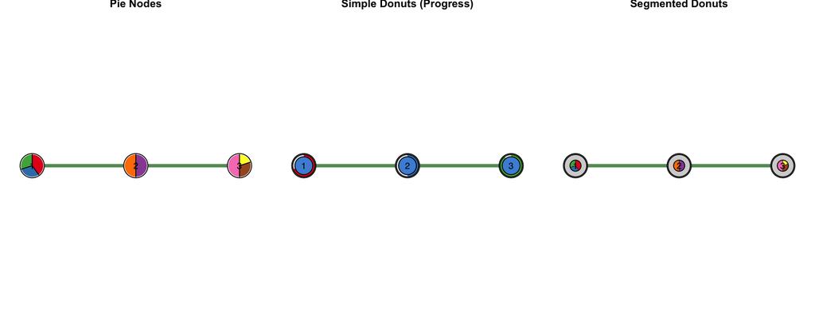

```r
# Create a simple 3-node network for comparison
adj <- matrix(c(0, 1, 0,
                1, 0, 1,
                0, 1, 0), nrow = 3, byrow = TRUE)

layout <- matrix(c(-1, 0,
                    0, 0,
                    1, 0), nrow = 3, byrow = TRUE)

par(mfrow = c(1, 3), mar = c(2, 1, 3, 1))

# Pie node
splot(adj, layout = layout,
      pie_values = list(c(0.4, 0.3, 0.3), c(0.5, 0.5), c(0.2, 0.3, 0.5)),
      pie_colors = list(c("#E41A1C", "#377EB8", "#4DAF4A"),
                        c("#984EA3", "#FF7F00"),
                        c("#FFFF33", "#A65628", "#F781BF")),
      node_size = 7,
      title = "Pie Nodes")

# Simple donut
splot(adj, layout = layout,
      donut_fill = c(0.7, 0.5, 0.9),
      donut_color = c("#E41A1C", "#377EB8", "#4DAF4A"),
      node_size = 7,
      title = "Simple Donuts (Progress)")

# Segmented donut
splot(adj, layout = layout,
      pie_values = list(c(0.4, 0.3, 0.3), c(0.5, 0.5), c(0.2, 0.3, 0.5)),
      pie_colors = list(c("#E41A1C", "#377EB8", "#4DAF4A"),
                        c("#984EA3", "#FF7F00"),
                        c("#FFFF33", "#A65628", "#F781BF")),
      donut_fill = c(1, 1, 1),  # Use donut mode
      donut_inner_ratio = 0.5,
      node_size = 7,
      title = "Segmented Donuts")
```

```r
par(mfrow = c(1, 1))
```

# Pie Chart Nodes

Pie chart nodes divide the node area into colored segments proportional to your data values.

## Basic Pie Nodes

Use `pie_values` to specify the proportions for each node. Values are automatically normalized to sum to 1.

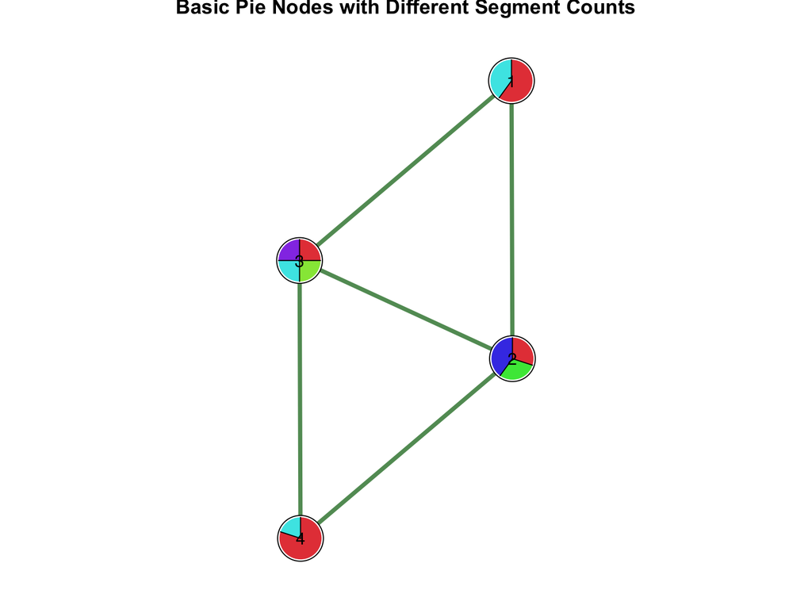

```r
# Simple 4-node network
adj <- matrix(c(0, 1, 1, 0,
                1, 0, 1, 1,
                1, 1, 0, 1,
                0, 1, 1, 0), nrow = 4, byrow = TRUE)

# Each node gets a list of values
splot(adj,
      pie_values = list(
        c(0.6, 0.4),           # Node 1: 2 segments
        c(0.3, 0.3, 0.4),      # Node 2: 3 segments
        c(0.25, 0.25, 0.25, 0.25), # Node 3: 4 segments
        c(0.8, 0.2)            # Node 4: 2 segments
      ),
      node_size = 6,
      title = "Basic Pie Nodes with Different Segment Counts")
```

## Customizing Pie Colors

Use `pie_colors` to specify custom colors for each segment.

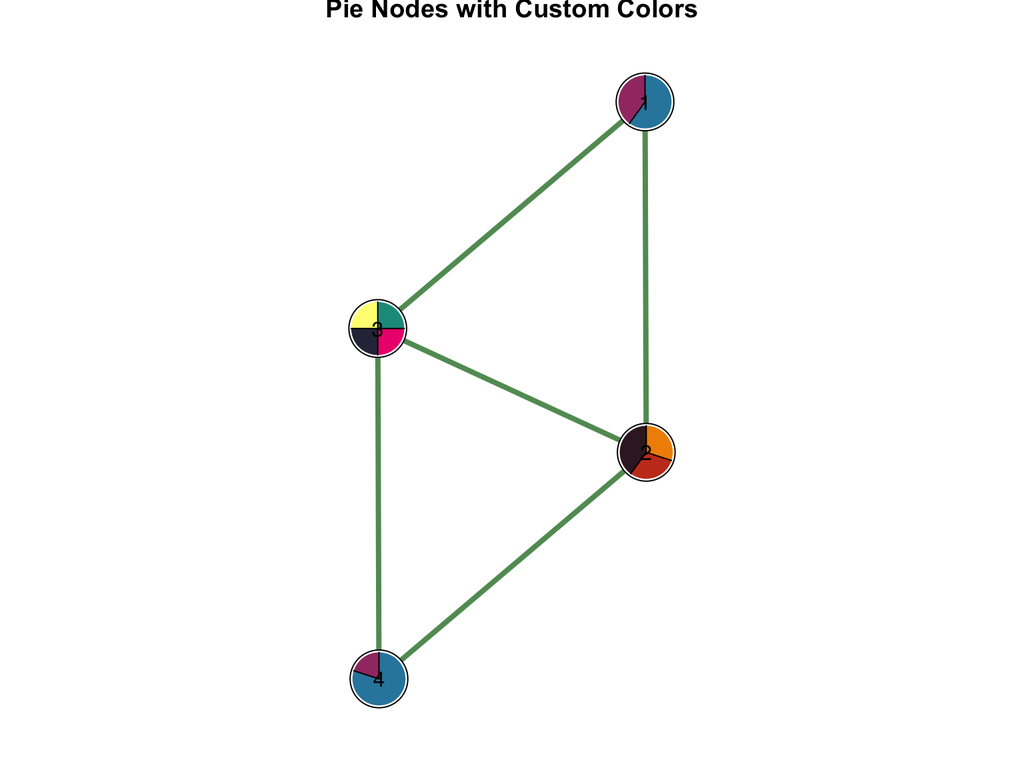

```r
# Professional color palette
colors_2seg <- c("#2E86AB", "#A23B72")
colors_3seg <- c("#F18F01", "#C73E1D", "#3B1F2B")
colors_4seg <- c("#1B998B", "#ED217C", "#2D3047", "#FFFD82")

splot(adj,
      pie_values = list(
        c(0.6, 0.4),
        c(0.3, 0.3, 0.4),
        c(0.25, 0.25, 0.25, 0.25),
        c(0.8, 0.2)
      ),
      pie_colors = list(
        colors_2seg,
        colors_3seg,
        colors_4seg,
        colors_2seg
      ),
      node_size = 6,
      title = "Pie Nodes with Custom Colors")
```

## Styling Pie Borders

Customize the border around pie charts using `pie_border_width` and node border parameters.

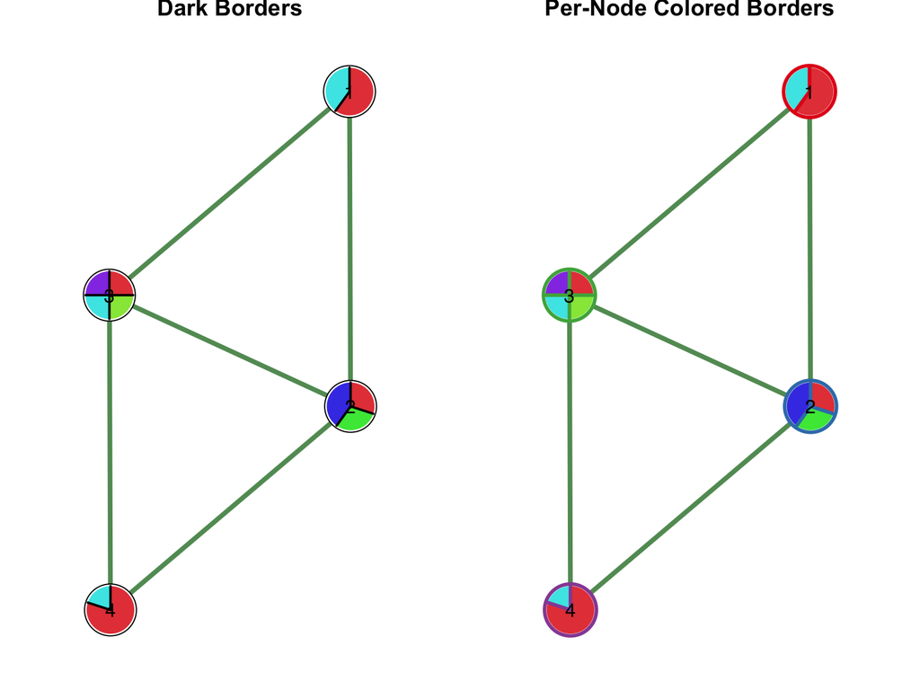

```r
par(mfrow = c(1, 2))

# Standard borders
splot(adj,
      pie_values = list(c(0.6, 0.4), c(0.3, 0.3, 0.4),
                        c(0.25, 0.25, 0.25, 0.25), c(0.8, 0.2)),
      node_border_color = "black",
      pie_border_width = 2,
      node_size = 6,
      title = "Dark Borders")

# Colored borders per node
splot(adj,
      pie_values = list(c(0.6, 0.4), c(0.3, 0.3, 0.4),
                        c(0.25, 0.25, 0.25, 0.25), c(0.8, 0.2)),
      node_border_color = c("#E41A1C", "#377EB8", "#4DAF4A", "#984EA3"),
      node_border_width = 3,
      node_size = 6,
      title = "Per-Node Colored Borders")
```

```r
par(mfrow = c(1, 1))
```

## Real-World Example: Category Distributions

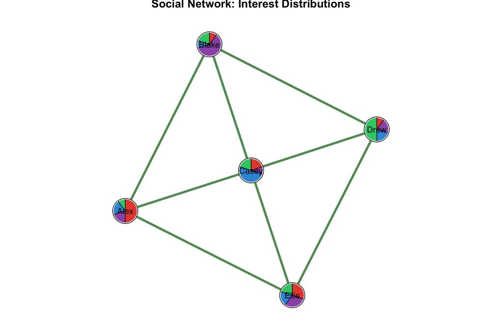

```r
# Social network with interest categories
adj <- matrix(c(
  0, 1, 1, 0, 1,
  1, 0, 1, 1, 0,
  1, 1, 0, 1, 1,
  0, 1, 1, 0, 1,
  1, 0, 1, 1, 0
), nrow = 5, byrow = TRUE)

# Interest distribution per person (Sports, Music, Tech, Art)
interests <- list(
  c(0.5, 0.2, 0.2, 0.1),  # Person 1: Sports fan
  c(0.1, 0.6, 0.1, 0.2),  # Person 2: Music lover
  c(0.2, 0.1, 0.5, 0.2),  # Person 3: Tech enthusiast
  c(0.1, 0.2, 0.2, 0.5),  # Person 4: Artist
  c(0.3, 0.3, 0.2, 0.2)   # Person 5: Balanced
)

interest_colors <- c("#E74C3C", "#9B59B6", "#3498DB", "#2ECC71")

splot(adj,
      layout = "fr",
      pie_values = interests,
      pie_colors = rep(list(interest_colors), 5),
      node_size = 6,
      labels = c("Alex", "Blake", "Casey", "Drew", "Ellis"),
      label_size = 0.9,
      title = "Social Network: Interest Distributions")
```

# Simple Donut Nodes (Progress Rings)

Simple donuts display a single value (0-1) as a filled ring, perfect for showing progress or completion.

## Basic Progress Donuts

Use `donut_fill` with values between 0 and 1 to show progress.

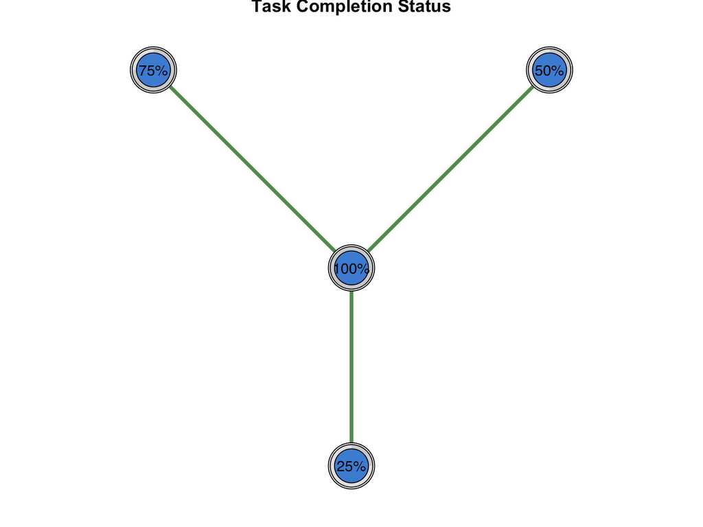

```r
adj <- matrix(c(0, 1, 1, 1,
                1, 0, 0, 0,
                1, 0, 0, 0,
                1, 0, 0, 0), nrow = 4, byrow = TRUE)

layout <- matrix(c(0, 0,
                   -1, 1,
                   1, 1,
                   0, -1), nrow = 4, byrow = TRUE)

splot(adj, layout = layout,
      donut_fill = c(1.0, 0.75, 0.5, 0.25),
      node_size = 7,
      labels = c("100%", "75%", "50%", "25%"),
      title = "Task Completion Status")
```

## Customizing Donut Colors

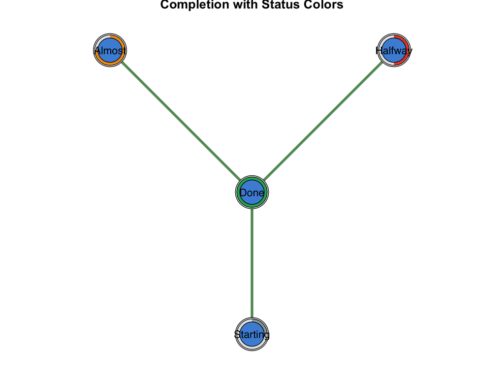

```r
# Color by completion level
completion_colors <- c("#27AE60", "#F39C12", "#E74C3C", "#95A5A6")

splot(adj, layout = layout,
      donut_fill = c(1.0, 0.75, 0.5, 0.25),
      donut_color = completion_colors,
      node_size = 7,
      labels = c("Done", "Almost", "Halfway", "Starting"),
      title = "Completion with Status Colors")
```

## Showing Values in Center

Enable `donut_show_value = TRUE` to display the numeric value inside the donut.

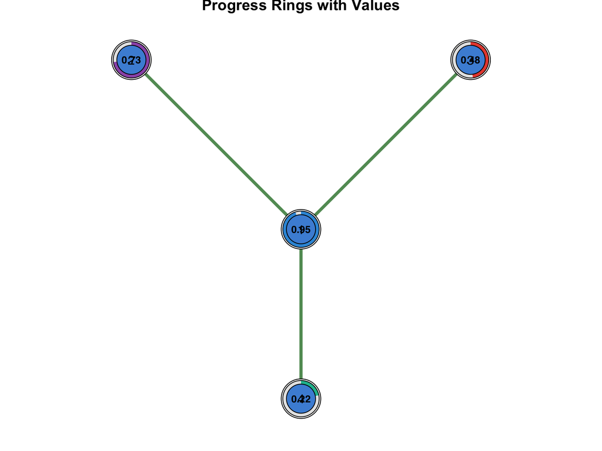

```r
splot(adj, layout = layout,
      donut_fill = c(0.95, 0.73, 0.48, 0.22),
      donut_color = c("#3498DB", "#9B59B6", "#E74C3C", "#1ABC9C"),
      donut_show_value = TRUE,
      node_size = 7,
      title = "Progress Rings with Values")
```

## Formatting Displayed Values

Customize value display with prefix, suffix, and digit precision.

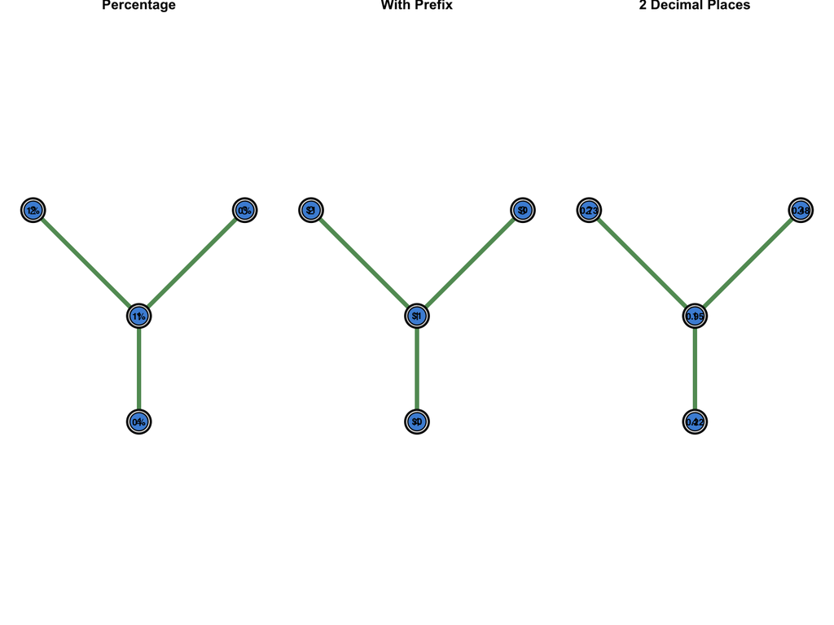

```r
par(mfrow = c(1, 3))

# Percentage format
splot(adj, layout = layout,
      donut_fill = c(0.95, 0.73, 0.48, 0.22),
      donut_show_value = TRUE,
      donut_value_suffix = "%",
      donut_value_digits = 0,
      node_size = 7,
      title = "Percentage")

# Prefix format
splot(adj, layout = layout,
      donut_fill = c(0.95, 0.73, 0.48, 0.22),
      donut_show_value = TRUE,
      donut_value_prefix = "$",
      donut_value_digits = 0,
      node_size = 7,
      title = "With Prefix")

# Decimal precision
splot(adj, layout = layout,
      donut_fill = c(0.95, 0.73, 0.48, 0.22),
      donut_show_value = TRUE,
      donut_value_digits = 2,
      node_size = 7,
      title = "2 Decimal Places")
```

```r
par(mfrow = c(1, 1))
```

# Donut Customization

## Controlling Hole Size with `donut_inner_ratio`

The `donut_inner_ratio` parameter controls the size of the inner hole (0 = no hole, 1 = all hole).

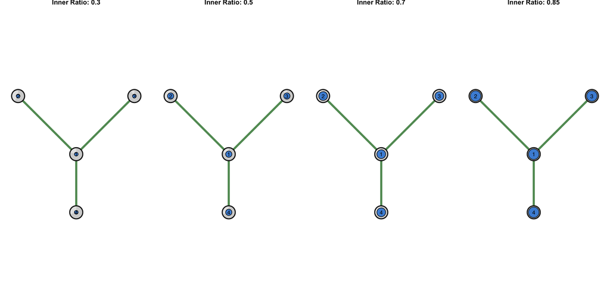

```r
par(mfrow = c(1, 4))

for (ratio in c(0.3, 0.5, 0.7, 0.85)) {
  splot(adj, layout = layout,
        donut_fill = c(0.8, 0.6, 0.9, 0.7),
        donut_inner_ratio = ratio,
        node_size = 7,
        title = paste("Inner Ratio:", ratio))
}
```

```r
par(mfrow = c(1, 1))
```

## Background Color for Unfilled Portions

Use `donut_bg_color` to change the color of unfilled donut sections.

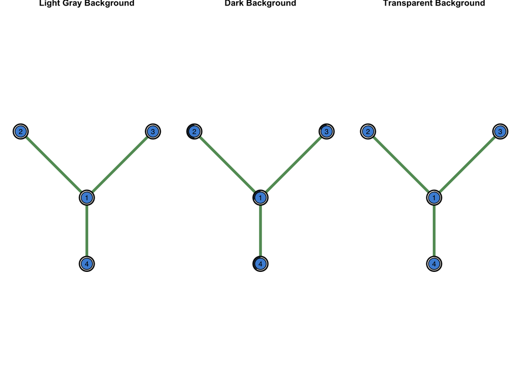

```r
par(mfrow = c(1, 3))

splot(adj, layout = layout,
      donut_fill = c(0.7, 0.5, 0.8, 0.6),
      donut_bg_color = "#EEEEEE",
      node_size = 7,
      title = "Light Gray Background")

splot(adj, layout = layout,
      donut_fill = c(0.7, 0.5, 0.8, 0.6),
      donut_bg_color = "#2C3E50",
      node_size = 7,
      title = "Dark Background")

splot(adj, layout = layout,
      donut_fill = c(0.7, 0.5, 0.8, 0.6),
      donut_bg_color = "transparent",
      node_size = 7,
      title = "Transparent Background")
```

```r
par(mfrow = c(1, 1))
```

## Polygon Shapes with `donut_shape`

Transform donuts into polygons: hexagon, square, diamond, triangle, or pentagon.

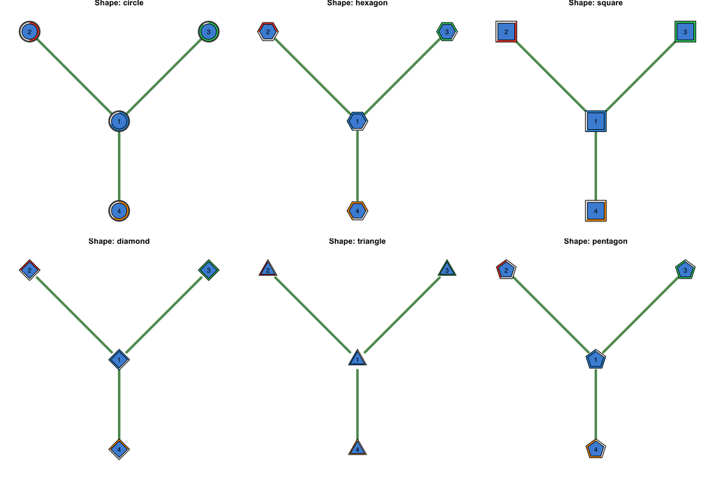

```r
shapes <- c("circle", "hexagon", "square", "diamond", "triangle", "pentagon")

par(mfrow = c(2, 3))

for (shape in shapes) {
  splot(adj, layout = layout,
        donut_fill = c(0.7, 0.5, 0.9, 0.6),
        donut_shape = shape,
        donut_color = c("#3498DB", "#E74C3C", "#2ECC71", "#F39C12"),
        node_size = 7,
        title = paste("Shape:", shape))
}
```

```r
par(mfrow = c(1, 1))
```

# Border Styling (Advanced)

Sonnet provides extensive border customization options for donut nodes, including double borders and line type patterns.

## Single Border Customization

Use `donut_border_color` to set the border color.

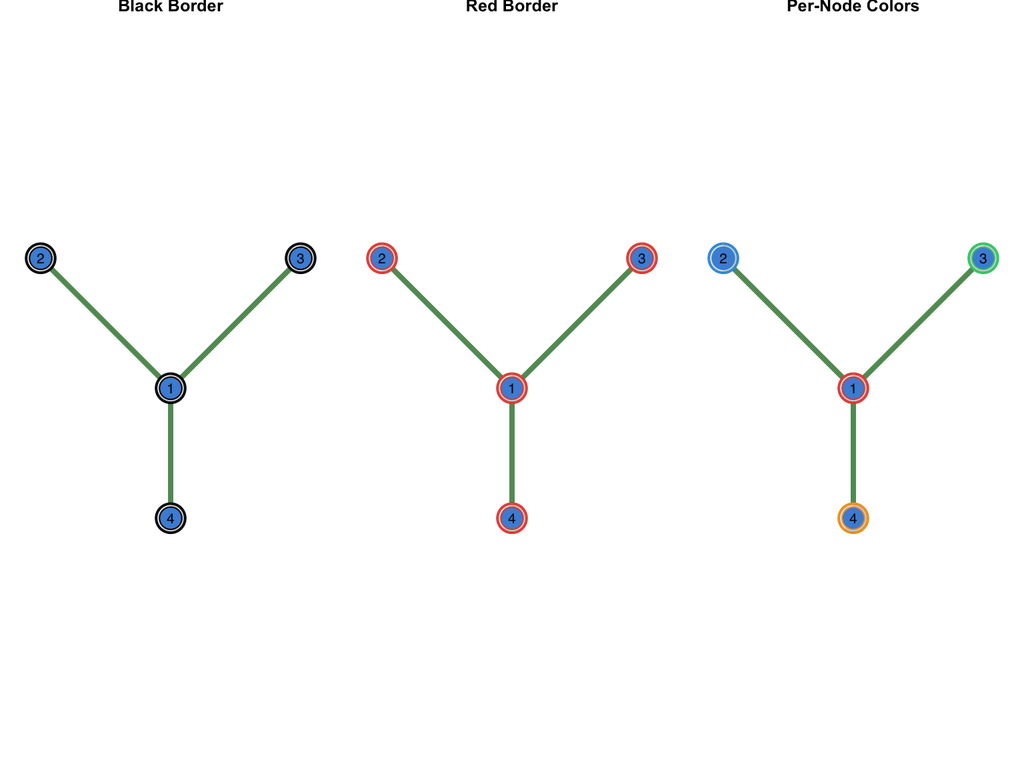

```r
par(mfrow = c(1, 3))

splot(adj, layout = layout,
      donut_fill = c(0.7, 0.5, 0.9, 0.6),
      donut_border_color = "black",
      node_size = 7,
      title = "Black Border")

splot(adj, layout = layout,
      donut_fill = c(0.7, 0.5, 0.9, 0.6),
      donut_border_color = "#E74C3C",
      node_size = 7,
      title = "Red Border")

# Per-node border colors
splot(adj, layout = layout,
      donut_fill = c(0.7, 0.5, 0.9, 0.6),
      donut_border_color = c("#E74C3C", "#3498DB", "#2ECC71", "#F39C12"),
      node_size = 7,
      title = "Per-Node Colors")
```

```r
par(mfrow = c(1, 1))
```

## Double Borders with `donut_outer_border_color`

Create a double-border effect by specifying both inner and outer border colors.

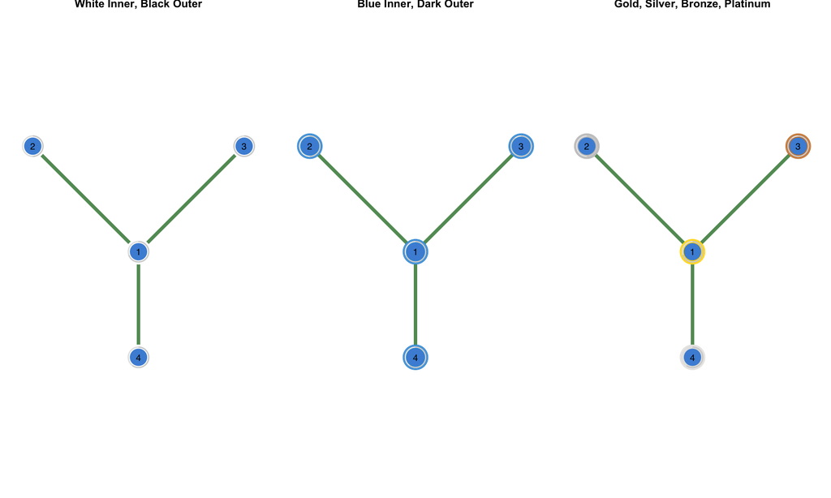

```r
par(mfrow = c(1, 3))

# Classic double border
splot(adj, layout = layout,
      donut_fill = c(0.7, 0.5, 0.9, 0.6),
      donut_border_color = "white",
      donut_outer_border_color = "black",
      node_size = 7,
      title = "White Inner, Black Outer")

# Colored double border
splot(adj, layout = layout,
      donut_fill = c(0.7, 0.5, 0.9, 0.6),
      donut_border_color = "#3498DB",
      donut_outer_border_color = "#2C3E50",
      node_size = 7,
      title = "Blue Inner, Dark Outer")

# Per-node double borders
splot(adj, layout = layout,
      donut_fill = c(0.7, 0.5, 0.9, 0.6),
      donut_border_color = c("#FFD700", "#C0C0C0", "#CD7F32", "#E5E4E2"),
      donut_outer_border_color = c("#B8860B", "#808080", "#8B4513", "#71706E"),
      node_size = 7,
      title = "Gold, Silver, Bronze, Platinum")
```

```r
par(mfrow = c(1, 1))
```

## Line Types with `donut_border_lty`

The `donut_border_lty` parameter accepts R’s standard line type values:

| Value | Name | Description |
| --- | --- | --- |
| 0 | “blank” | No line |
| 1 | “solid” | Solid line (default) |
| 2 | “dashed” | Dashed line |
| 3 | “dotted” | Dotted line |
| 4 | “dotdash” | Dot-dash pattern |
| 5 | “longdash” | Long dashes |
| 6 | “twodash” | Two-dash pattern |

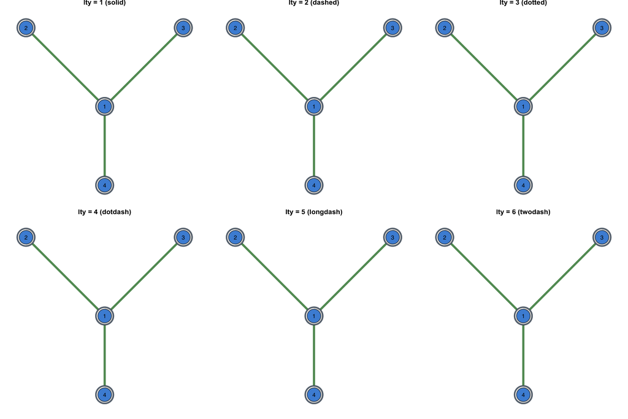

```r
lty_values <- c(1, 2, 3, 4, 5, 6)
lty_names <- c("solid", "dashed", "dotted", "dotdash", "longdash", "twodash")

par(mfrow = c(2, 3))

for (i in seq_along(lty_values)) {
  splot(adj, layout = layout,
        donut_fill = c(0.7, 0.5, 0.9, 0.6),
        donut_border_color = "#2C3E50",
        donut_border_lty = lty_values[i],
        node_size = 7,
        title = paste0("lty = ", lty_values[i], " (", lty_names[i], ")"))
}
```

```r
par(mfrow = c(1, 1))
```

## Per-Node Line Types

Assign different line types to individual nodes.

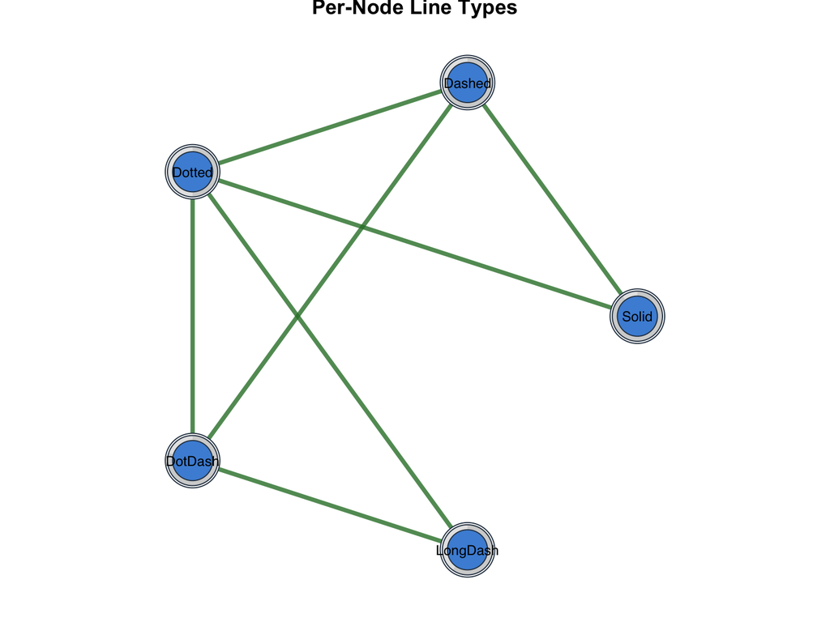

```r
# 5-node network
adj5 <- matrix(c(
  0, 1, 1, 0, 0,
  1, 0, 1, 1, 0,
  1, 1, 0, 1, 1,
  0, 1, 1, 0, 1,
  0, 0, 1, 1, 0
), nrow = 5, byrow = TRUE)

# Create circle layout manually
n <- 5
angles <- seq(0, 2 * pi, length.out = n + 1)[1:n]
circle_layout <- cbind(cos(angles), sin(angles))

splot(adj5,
      layout = circle_layout,
      donut_fill = c(0.9, 0.7, 0.5, 0.8, 0.6),
      donut_border_color = "#2C3E50",
      donut_border_lty = c(1, 2, 3, 4, 5),
      node_size = 7,
      labels = c("Solid", "Dashed", "Dotted", "DotDash", "LongDash"),
      label_size = 0.8,
      title = "Per-Node Line Types")
```

## Combining Double Borders with Line Types

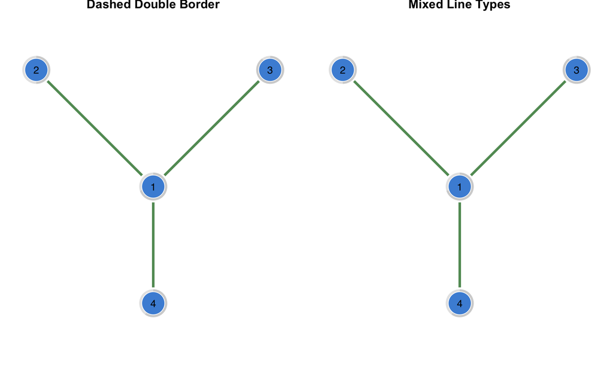

```r
par(mfrow = c(1, 2))

# Dashed outer border
splot(adj, layout = layout,
      donut_fill = c(0.7, 0.5, 0.9, 0.6),
      donut_border_color = "white",
      donut_outer_border_color = "#E74C3C",
      donut_border_lty = 2,
      node_size = 8,
      title = "Dashed Double Border")

# Different line types per node
splot(adj, layout = layout,
      donut_fill = c(0.7, 0.5, 0.9, 0.6),
      donut_border_color = "white",
      donut_outer_border_color = c("#E74C3C", "#3498DB", "#2ECC71", "#F39C12"),
      donut_border_lty = c(1, 2, 3, 4),
      node_size = 8,
      title = "Mixed Line Types")
```

```r
par(mfrow = c(1, 1))
```

# Donut + Pie Combinations

For truly data-rich visualizations, combine donut rings with inner pie charts or use multiple donut layers.

## Outer Donut Ring with Inner Pie Chart

Use both `donut_fill` AND `pie_values` together.

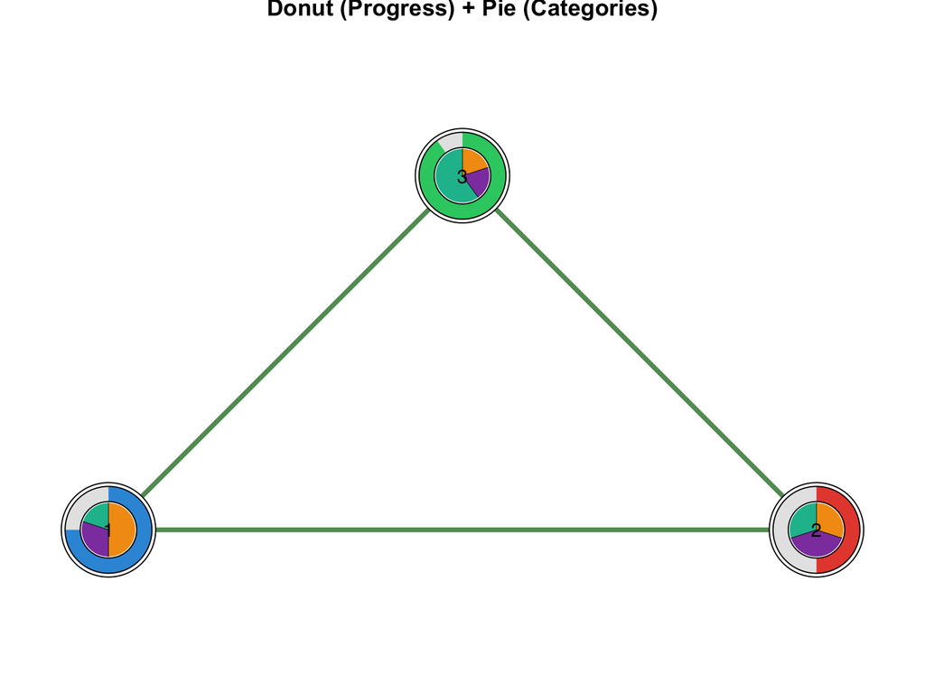

```r
adj3 <- matrix(c(0, 1, 1,
                 1, 0, 1,
                 1, 1, 0), nrow = 3, byrow = TRUE)

layout3 <- matrix(c(-1, 0, 1, 0, 0, 1), nrow = 3, byrow = TRUE)

splot(adj3, layout = layout3,
      # Outer donut: progress/completion
      donut_fill = c(0.75, 0.5, 0.9),
      donut_color = c("#3498DB", "#E74C3C", "#2ECC71"),
      donut_inner_ratio = 0.65,
      # Inner pie: category breakdown
      pie_values = list(
        c(0.5, 0.3, 0.2),
        c(0.3, 0.4, 0.3),
        c(0.2, 0.2, 0.6)
      ),
      pie_colors = list(
        c("#F39C12", "#8E44AD", "#1ABC9C"),
        c("#F39C12", "#8E44AD", "#1ABC9C"),
        c("#F39C12", "#8E44AD", "#1ABC9C")
      ),
      node_size = 8,
      title = "Donut (Progress) + Pie (Categories)")
```

## Double Donut Configuration

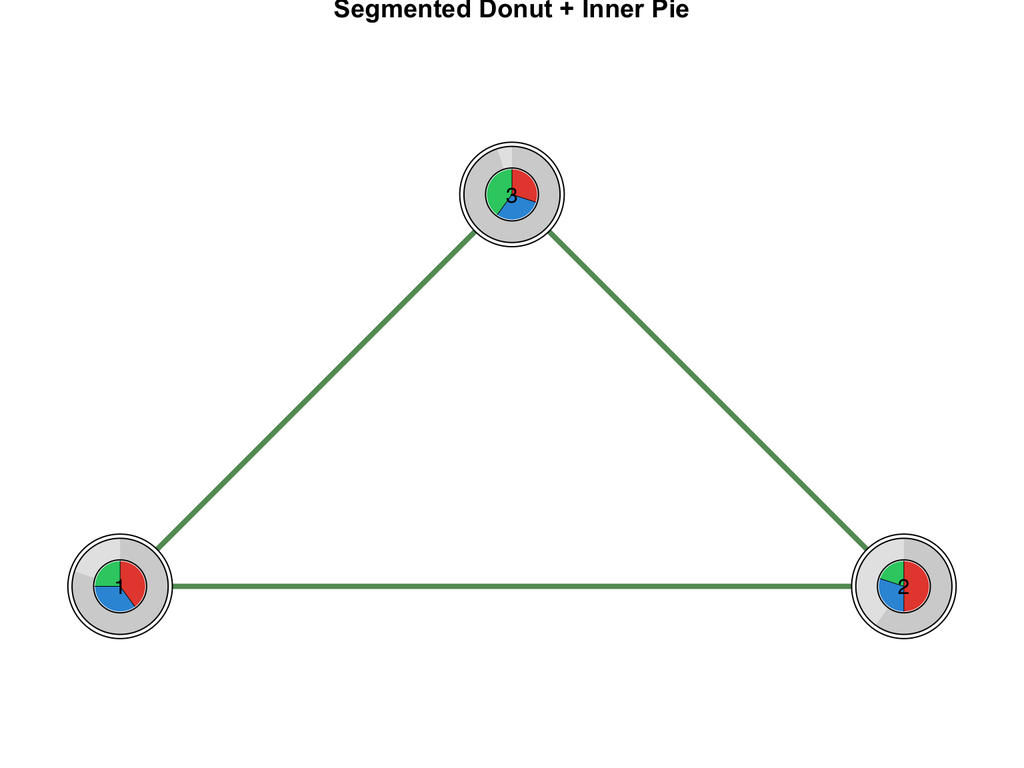

```r
# Use segmented outer donut with a simple fill creating a visual double effect
splot(adj3, layout = layout3,
      pie_values = list(
        c(0.4, 0.35, 0.25),
        c(0.5, 0.3, 0.2),
        c(0.3, 0.3, 0.4)
      ),
      pie_colors = list(
        c("#E74C3C", "#3498DB", "#2ECC71"),
        c("#E74C3C", "#3498DB", "#2ECC71"),
        c("#E74C3C", "#3498DB", "#2ECC71")
      ),
      donut_fill = c(0.8, 0.6, 0.95),
      donut_inner_ratio = 0.55,
      donut_border_color = "white",
      donut_outer_border_color = "#2C3E50",
      node_size = 8,
      title = "Segmented Donut + Inner Pie")
```

# Real-World Examples

## Example 1: Project Completion Dashboard

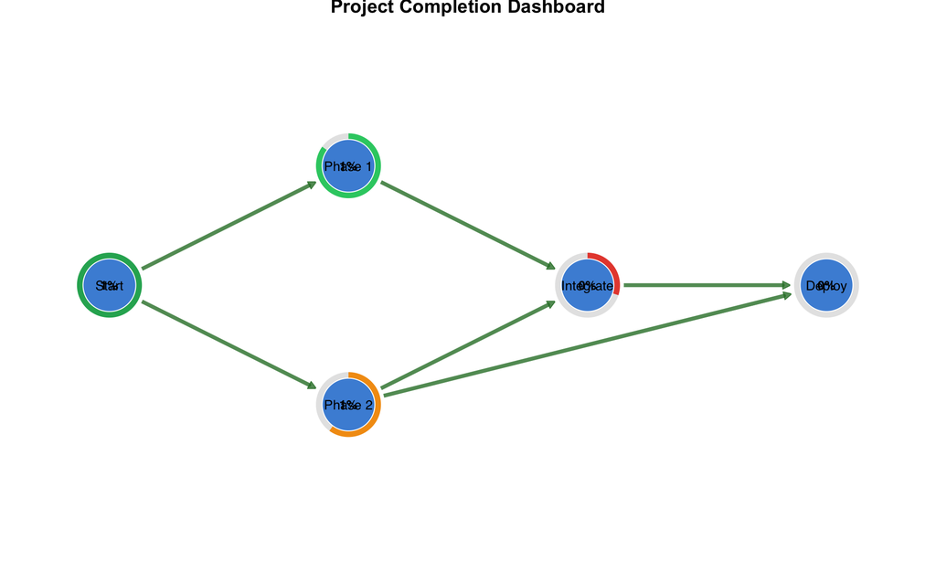

```r
# Project dependency network
proj_adj <- matrix(c(
  0, 1, 1, 0, 0,
  0, 0, 0, 1, 0,
  0, 0, 0, 1, 1,
  0, 0, 0, 0, 1,
  0, 0, 0, 0, 0
), nrow = 5, byrow = TRUE)

# Layout suggesting flow
proj_layout <- matrix(c(
  -2, 0,    # Start
  -1, 0.5,  # Phase 1
  -1, -0.5, # Phase 2
  0, 0,     # Integration
  1, 0      # Deploy
), nrow = 5, byrow = TRUE)

# Completion percentages
completion <- c(1.0, 0.85, 0.6, 0.3, 0.0)

# Color by status
status_colors <- c("#27AE60", "#2ECC71", "#F39C12", "#E74C3C", "#95A5A6")

splot(proj_adj, layout = proj_layout,
      donut_fill = completion,
      donut_color = status_colors,
      donut_show_value = TRUE,
      donut_value_suffix = "%",
      donut_value_digits = 0,
      donut_border_color = "white",
      donut_outer_border_color = "#2C3E50",
      node_size = 6,
      labels = c("Start", "Phase 1", "Phase 2", "Integrate", "Deploy"),
      label_size = 0.85,
      arrow_size = 0.5,
      title = "Project Completion Dashboard")
```

## Example 2: Team Skills Network

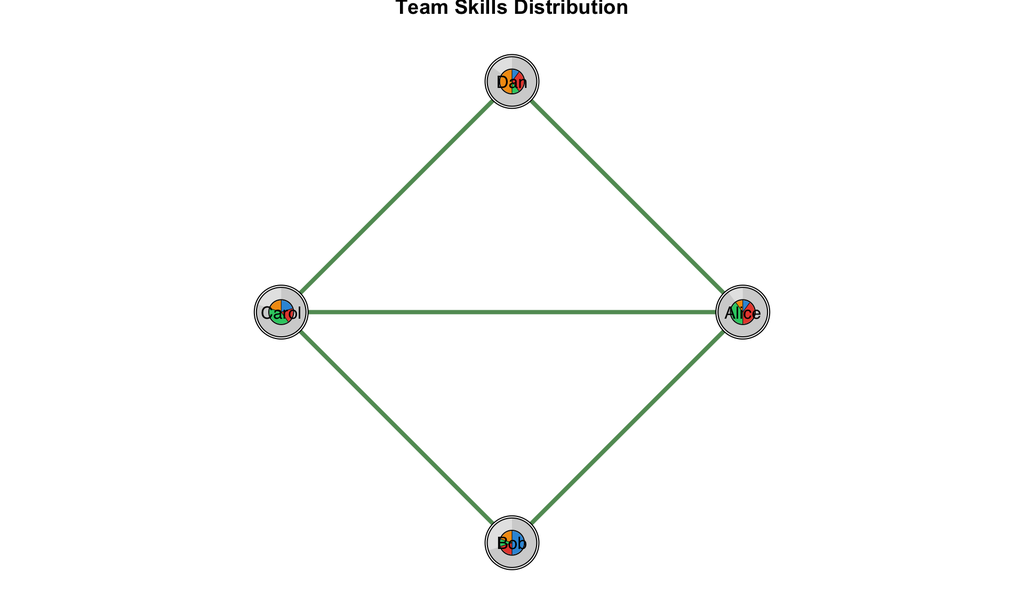

```r
# Team collaboration network
team_adj <- matrix(c(
  0, 1, 1, 1,
  1, 0, 1, 0,
  1, 1, 0, 1,
  1, 0, 1, 0
), nrow = 4, byrow = TRUE)

# Skill breakdown: Frontend, Backend, Data, DevOps
skill_colors <- c("#3498DB", "#E74C3C", "#2ECC71", "#F39C12")

skills <- list(
  c(0.1, 0.4, 0.4, 0.1),  # Alice: Backend + Data
  c(0.5, 0.2, 0.1, 0.2),  # Bob: Frontend
  c(0.2, 0.2, 0.4, 0.2),  # Carol: Data focused
  c(0.1, 0.3, 0.1, 0.5)   # Dan: DevOps
)

splot(team_adj,
      layout = "circle",
      pie_values = skills,
      pie_colors = rep(list(skill_colors), 4),
      donut_fill = c(0.9, 0.7, 0.8, 0.85),
      donut_inner_ratio = 0.5,
      donut_border_color = "white",
      node_size = 7,
      labels = c("Alice", "Bob", "Carol", "Dan"),
      label_size = 1.0,
      title = "Team Skills Distribution")
```

## Example 3: Multi-Metric Node Visualization

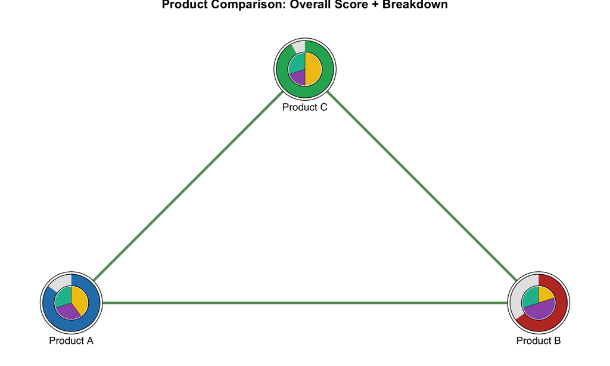

```r
# 3-node comparison
comp_adj <- matrix(c(0, 1, 1, 1, 0, 1, 1, 1, 0), nrow = 3, byrow = TRUE)
comp_layout <- matrix(c(-1, 0, 1, 0, 0, 1), nrow = 3, byrow = TRUE)

# Outer donut: Overall score
# Inner pie: Score breakdown (Quality, Speed, Cost)
splot(comp_adj, layout = comp_layout,
      # Outer: Overall performance (0-1)
      donut_fill = c(0.85, 0.65, 0.92),
      donut_color = c("#2980B9", "#C0392B", "#27AE60"),
      donut_inner_ratio = 0.6,
      donut_border_color = "white",
      donut_outer_border_color = "#2C3E50",
      donut_border_lty = c(1, 2, 1),  # Dashed for middle node
      # Inner: Breakdown
      pie_values = list(
        c(0.4, 0.3, 0.3),  # Balanced
        c(0.2, 0.5, 0.3),  # Speed focused
        c(0.5, 0.2, 0.3)   # Quality focused
      ),
      pie_colors = rep(list(c("#F1C40F", "#9B59B6", "#1ABC9C")), 3),
      node_size = 8,
      labels = c("Product A", "Product B", "Product C"),
      label_position = "below",
      title = "Product Comparison: Overall Score + Breakdown")
```

# Parameter Reference

## Pie Chart Parameters

| Parameter | Type | Default | Description |
| --- | --- | --- | --- |
| `pie_values` | list | NULL | List of numeric vectors with proportions per node |
| `pie_colors` | list/vector | Default palette | Colors for pie segments |
| `pie_border_width` | numeric | NULL | Border width for pie slice dividers |

## Donut Parameters

| Parameter | Type | Default | Description |
| --- | --- | --- | --- |
| `donut_fill` | numeric | NULL | Single values (0-1) for progress donuts |
| `donut_color` | vector | Default palette | Colors for donut segments |
| `donut_inner_ratio` | numeric | 0.5 | Size of inner hole (0-1) |
| `donut_bg_color` | character | “#EEEEEE” | Background for unfilled portions |
| `donut_shape` | character | “circle” | Shape: circle, hexagon, square, diamond, triangle, pentagon |
| `donut_show_value` | logical | FALSE | Display value in center |
| `donut_value_prefix` | character | “” | Prefix for displayed value |
| `donut_value_suffix` | character | “” | Suffix for displayed value |
| `donut_value_digits` | integer | 2 | Decimal places for displayed value |
| `donut_empty` | logical | TRUE | Render empty rings for NA values |

## Donut Border Parameters

| Parameter | Type | Default | Description |
| --- | --- | --- | --- |
| `donut_border_color` | character | “black” | Inner border color |
| `donut_border_width` | numeric | NULL | Border width (uses node_border_width if NULL) |
| `donut_outer_border_color` | character | NULL | Outer border color (enables double border) |
| `donut_border_lty` | numeric/character | 1 | Line type: 0-6 or “blank”, “solid”, etc. |

## Double Donut Parameters

| Parameter | Type | Default | Description |
| --- | --- | --- | --- |
| `donut2_values` | list | NULL | Values for inner donut ring |
| `donut2_colors` | list | NULL | Colors for inner donut ring |
| `donut2_inner_ratio` | numeric | 0.4 | Inner radius ratio for inner donut |

# Conclusion

Sonnet’s pie and donut node features transform simple network diagrams into rich, multi-dimensional visualizations. Whether you need to show completion status, category breakdowns, or multiple metrics per node, these tools provide the flexibility to create exactly the visualization you need.

Key takeaways:

- **Pie charts** are ideal for showing composition/category data
- **Simple donuts** excel at progress/completion metrics
- **Double borders** and **line types** add visual hierarchy
- **Combinations** (donut + pie) enable multi-metric displays
- **Custom shapes** (hexagon, square, etc.) provide visual variety

For more examples and advanced usage, see the package documentation with `?splot` or visit the Sonnet GitHub repository.

*Generated by Sonnet package v1.2.7*